# Meta-analysis tutorial

16/09/2020

## Meta-Analysis

Meta-analysis is the statistical combination of two or more studies.

It forms the analytic component of a quantitative systematic review.

Meta-analyses of high quality randomised trials are considered to be the **highest level of available evidence** for health care interventions.

Useful for:

- Improving *precision* (I.e. If many small studies)
- Answering *ancillary* questions (I.e. Non-primary outcomes)
- Address *conflicting* studies (I.e. Explore differences/compare pooled outcomes)

## Systematic reviews

### Planning

Systematic review is a research methodology identifying relevant literature using a *structured* and *pre-specified* approach to answer a research question.

Detailed protocols are expected as standard part of the methodology.

Lots of tools are available:

- Local library can often offer support
- PROSPERO (registry of systematic review protocols)
- PRISMA (**P**referred **R**eporting **I**tems for **S**ystematic reviews and **M**eta-**A**nalyses)
- [Cochrane Handbook](https://training.cochrane.org/handbook)

## Systematic reviews

### Performing

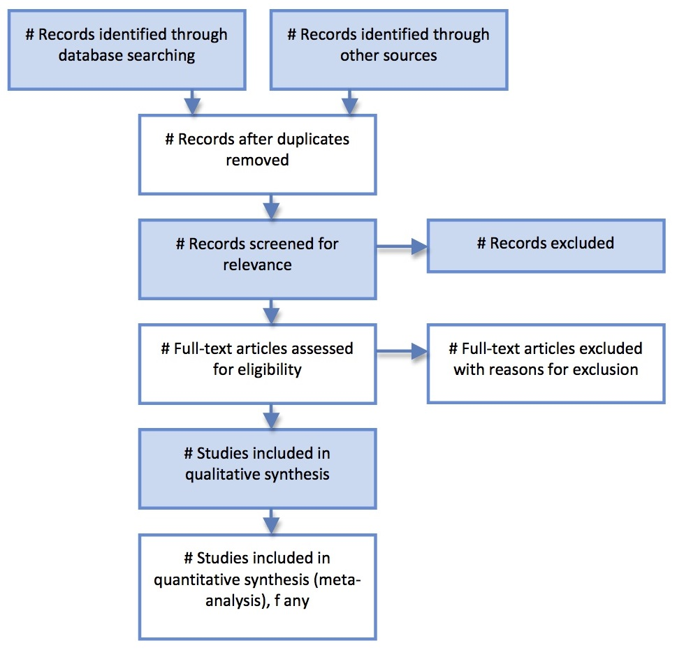

## Systematic reviews

### Getting data

[interactive chart not shown]

## Meta analysis

### A primer

Meta-analysis requires two things:

- Effect size/measure
- Some measure of variance

Individual study contributions to the pooled effect is based on the inverse of their variance.

We use variance also to determine \(\tau^2\) which is important for Random effects meta-analysis.

For binary outcome data, the *Mantel-Haenszel* method is generally preferred.

## Meta analysis

### A primer II

For example, to calculate study weight if using Risk Ratio; M-H:

\[w_k = \frac{(a_k+b_k)c_k}{n_k}\] Where :

- a = number of events in intervention group
- b = number of non events in intervention group
- c = number of events in control group
- n = total number of included patients

This is then used to determine a weighted average effect.

## Practice

### Data from {metafor}

Cochrane review of Cholera vaccines:

*Graves, P. M., Deeks, J. J., Demicheli, V., & Jefferson, T. (2010). Vaccines for preventing cholera: Killed whole cell or other subunit vaccines (injected). Cochrane Database of Systematic Reviews, 8, CD000974.*

```r
dat<-metafor::dat.graves2010
```

| study | ai | n1i | ci | n2i |
| --- | --- | --- | --- | --- |
| Oseasohn 1965 | 8 | 6956 | 33 | 7103 |
| McCormack 1969 | 44 | 29939 | 35 | 9923 |

## Practice

### Data description

| Column | Description |
| --- | --- |
| study | Author and year |
| ai | number of cholera cases in vaccinated group |
| n1i | number of individuals vaccinated |
| ci | number of cholera cases in placebo group |
| n2i | number of individuals in placebo group |

There are 17 studies included in this data set.

## Practice

### Binary outcome variable

We can use the `meta::metabin` function to analyse this data.

```r
mod <- meta::metabin(
  event.e = ai, #exposed to vaccine and had cholera
  n.e = n1i, # count of those exposed to vaccine
  event.c = ci, # not exposed to vaccine, had cholera
  n.c = n2i, # count of those not exposed to vaccine
  data = dat
)
```

## Practice

### Review model

```
##        RR           95%-CI %W(fixed) %W(random)
## 1  0.2475 [0.1144; 0.5355]       4.0        3.6
## 2  0.4167 [0.2675; 0.6491]       6.5        6.9
## 3  0.8162 [0.4288; 1.5534]       2.4        4.6
## 4  0.0555 [0.0124; 0.2480]       2.2        1.2
## 5  0.7234 [0.4654; 1.1242]       5.3        6.9
## 6  0.3825 [0.2813; 0.5202]      15.3        9.0
## 7  0.4103 [0.2445; 0.6883]       4.5        5.9
## 8  0.3623 [0.2113; 0.6211]       4.4        5.6
## 9  0.3891 [0.2307; 0.6563]       4.5        5.8
## 10 0.2921 [0.1657; 0.5152]       4.3        5.3
## 11 0.7114 [0.5116; 0.9893]       9.6        8.6
## 12 0.5846 [0.4161; 0.8212]       9.6        8.4
## 13 0.4653 [0.3254; 0.6653]       9.6        8.1
## 14 0.3937 [0.2072; 0.7479]       4.1        4.6
## 15 0.4456 [0.2969; 0.6686]       7.6        7.4
## 16 0.4804 [0.2521; 0.9152]       3.1        4.6
## 17 0.2830 [0.1306; 0.6129]       2.9        3.6
##
## Number of studies combined: k = 17
##
##                          RR           95%-CI      z  p-value
## Fixed effect model   0.4614 [0.4124; 0.5162] -13.51 < 0.0001
## Random effects model 0.4446 [0.3741; 0.5285]  -9.19 < 0.0001
##
## Quantifying heterogeneity:
##  tau^2 = 0.0622; tau = 0.2494; I^2 = 51.5% [15.6%; 72.2%]; H = 1.44 [1.09; 1.90]
##
## Test of heterogeneity:
##      Q d.f. p-value
##  33.01   16  0.0074
##
## Details on meta-analytical method:
## - Mantel-Haenszel method
## - DerSimonian-Laird estimator for tau^2
## - Mantel-Haenszel estimator used in calculation of Q and tau^2 (like RevMan 5)
```

## Practice

### Summary model

```r
summary(mod)
```

```
## Number of studies combined: k = 17
##
##                          RR           95%-CI      z  p-value
## Fixed effect model   0.4614 [0.4124; 0.5162] -13.51 < 0.0001
## Random effects model 0.4446 [0.3741; 0.5285]  -9.19 < 0.0001
##
## Quantifying heterogeneity:
##  tau^2 = 0.0622; tau = 0.2494; I^2 = 51.5% [15.6%; 72.2%]; H = 1.44 [1.09; 1.90]
##
## Test of heterogeneity:
##      Q d.f. p-value
##  33.01   16  0.0074
##
## Details on meta-analytical method:
## - Mantel-Haenszel method
## - DerSimonian-Laird estimator for tau^2
## - Mantel-Haenszel estimator used in calculation of Q and tau^2 (like RevMan 5)
```

## Practice

### Alter parameters

```r
u_mod <- update(mod, sm = 'RD')
summary(u_mod)
```

```
## Number of studies combined: k = 17
##
##                           RD             95%-CI      z  p-value
## Fixed effect model   -0.0005 [-0.0006; -0.0004] -11.80 < 0.0001
## Random effects model -0.0007 [-0.0010; -0.0005]  -5.58 < 0.0001
##
## Quantifying heterogeneity:
##  tau^2 < 0.0001; tau = 0.0004; I^2 = 90.3% [86.1%; 93.3%]; H = 3.22 [2.68; 3.86]
##
## Test of heterogeneity:
##       Q d.f.  p-value
##  165.48   16 < 0.0001
##
## Details on meta-analytical method:
## - Mantel-Haenszel method
## - DerSimonian-Laird estimator for tau^2
## - Mantel-Haenszel estimator used in calculation of Q and tau^2 (like RevMan 5)
```

## Practice

### Forest plot

We can use the `meta::forest` function to output a plot.

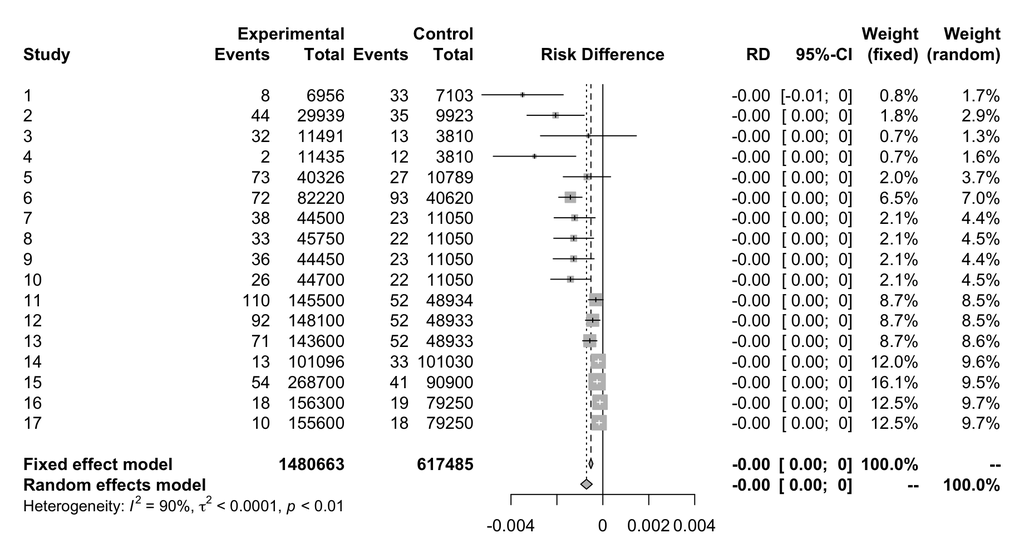

```r
forest_plot <- meta::forest(u_mod, yaxs="i")
```